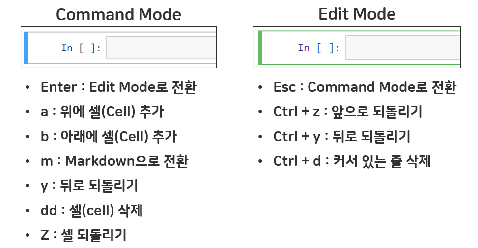

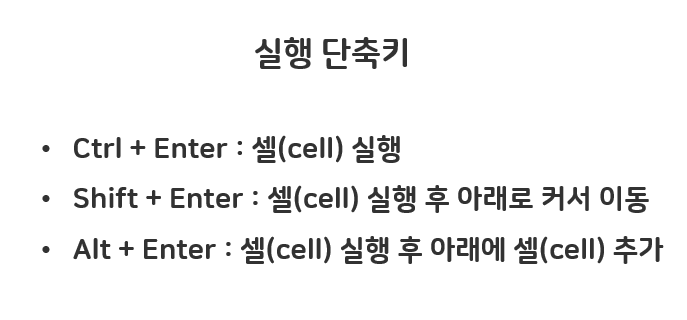

# 대단원

## 중단원

### 소단원

#### 학습목표

##### 학습내용(이탤릭체-기울임체)

### 주피터 노트북 사용 방법

- 셀(cell) : 코드 및 텍스트를 입력하는 공간
- command mode, edit mode
  - command mode : 앞쪽의 띠가 파란색(셀 단위의 작업을 할 수 있는 모드)
  - edit mode: 앞쪽의 띠가 초록색(셀 내부의 텍스트나 코드를 편집할 수 있는 모드)
- markdown : 셀 하나를 통째로 코드의 영향을 받지 않는 메모장 형태로 만들 때 사용
  - 사진 첨부 가능

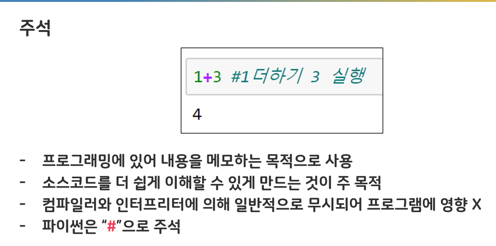

- window + shift + s : 캡처

```python
num = 3
print(num)
print(type(num))
```

```
3
<class 'int'>
```

- python의 특징 : 동적자료형
  - 동적자료형은 값을 넣어줌과 동시에 자료형이 정해짐
  - 변수 실행단계 runtime에서 만들어줌
- 영문자 ,숫자, 언더바 사용가능, 대소문자 구분
  - 숫자로 시작 불가능
  - 키워드 사용 불가능 진한초록색 ex. if, 내장함수 연한초록색은 사용 가능하긴 하나 권장 x
- 권장사항
  - 변수명의 첫글자는 항상 소문자
  - 두가지의 문자를 섞어 변수명을 만들경우, 두 단어를 구분

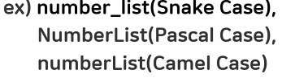

### 1)변수

```python
# 변수란? 데이터를 저장하는 공간
# num이라는 변수에 3이라는 값을 담아보자!
num = 3 #=은 대입연산자
```

```python
num2
```

```
2
```

```python
# 파이썬은 셀 단위로 실행되는 인터프리터 언어<->컴파일언어
# 위에서 아래로 흐르는게 아니라 실행 순으로 진행됨
num2 = 2
```

```python
# 키워드 사용 불가능(굵은 초록색 글씨)
import keyword
print(keyword.kwlist)
```

```
['False', 'None', 'True', 'and', 'as', 'assert', 'async', 'await', 'break', 'class', 'continue', 'def', 'del', 'elif', 'else', 'except', 'finally', 'for', 'from', 'global', 'if', 'import', 'in', 'is', 'lambda', 'nonlocal', 'not', 'or', 'pass', 'raise', 'return', 'try', 'while', 'with', 'yield']
```

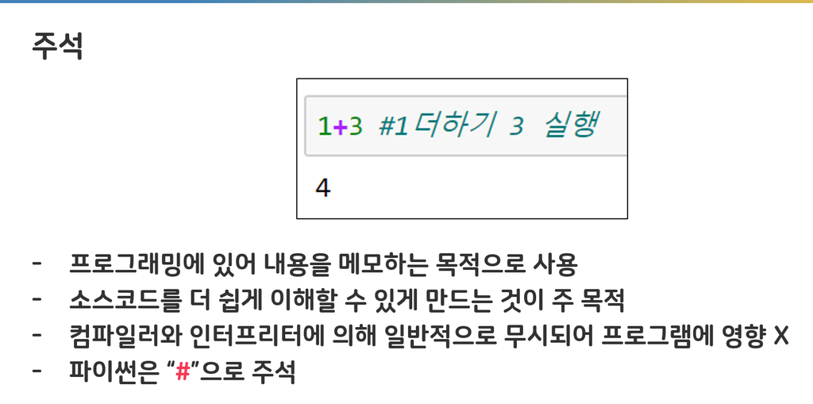

```python
False = 2
# 내가 줄을 주석처리하고 싶다면 ctrl + /
# 여러줄 처리는 선택후 ctrl + /

# print = 5
# print = 5
# print = 5
```

```
  Cell In[9], line 1
    False = 2
    ^
SyntaxError: cannot assign to False
```

```python
# 내장 함수명을 변수명으로 사용은 가능하지만 비권장(연두색 글씨)
# 이유는 함수 본래의 기능을 잃음
print = 4
```

```python
print()
```

```python
del print # del은 변수 삭제
```

자료형종류

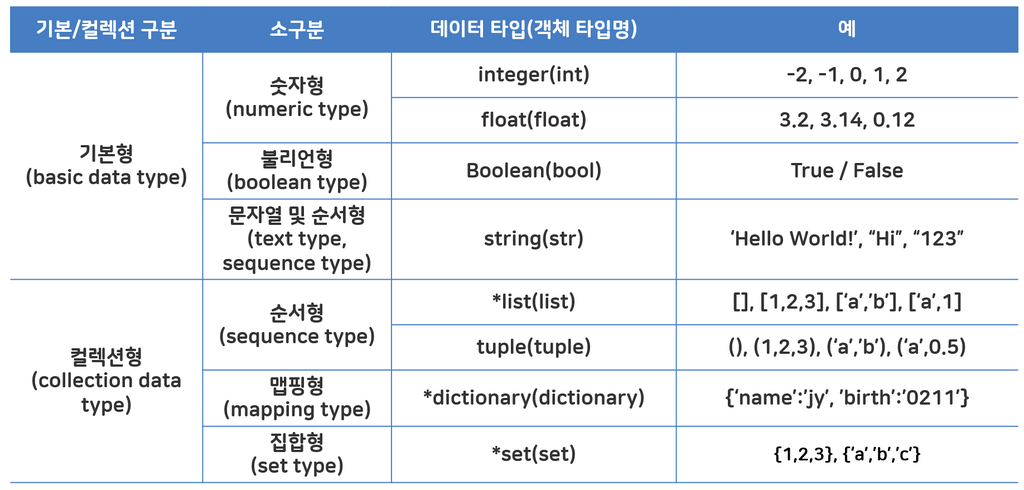

### 2)자료형

- 숫자(정수) : int
- 숫자(실수) : float
- 문자열 : str, 따옴표 기호를 사용(큰 따옴표, 작은따옴표 둘 다 사용가능!)
- 논리형(불리언형) : bool, True(참), False(거짓)

```python
# 정수형 데이터 변수에 대입
# num3이라는 변수에 13이라는 정수
num3 = 13
```

```python
# 실수형 데이터 변수에 대입
# num4라는 변수에 3.14라는 실수
num4 = 3.14
```

```python
print(num3, num4)
```

```
13 3.14
```

```python
# 문자열 데이터 변수에 대입
# str1 변수에 '즐거운 파이썬 수업'
str1 = "즐거운 파이썬 수업"
str2 = '즐거운 파이썬 수업'
```

```python
print(str1)
print(str2)
```

```
즐거운 파이썬 수업
즐거운 파이썬 수업
```

```python
# 변수 a에는 10, 변수 b에는 15를 대입하고 각각 출력
a = 10
b = 15
```

```python
print(a)
print(b)
```

```
10
15
```

```python
# 파이썬에서는 쉼표로구별해서 순서대로 대입이 가능
a, b = 10, 15

print(a, b)
```

```
10 15
```

```python
# 변수 str3과 str4 'python' 문자열 대입하고 각각 출력하기
str3, str4 = "python", "python"
print(str3)
print(str4)
```

```
python
python
```

```python
str3 = str4 = 'python'
print(str3, str4)
```

```
python python
```

### 3)문자열

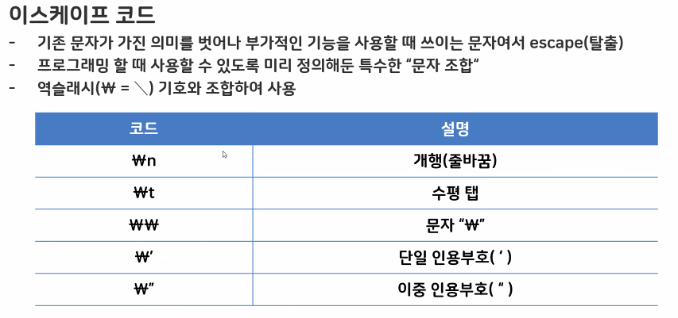

```python
#she's gone 문자열 안에 작은 따옴표나 큰 따옴표를 포함시키고 싶을 때
s = 'she\'s gone' # 이스케이프 코드 사용 (역슬래시 = \)
print(s)
s1 = "she's gone"
print(s1)
```

```
she's gone
she's gone
```

```python
# 이스케이프 코드 : 특수문자 출력을 위한 코드
s2 = '여러 줄로 구성된 문자열을 \n하나의 변수명에 \t대입하고 싶을 때'
print(s2)
```

```
여러 줄로 구성된 문자열을
하나의 변수명에 	대입하고 싶을 때
```

```python
s3 = '''
여기에 입력하고 싶은
내용을
입력한
다
'''
print(s3) # 따옴표 3개를 연속으로 써서 양쪽 둘러싸기

s3 = """
이래
저래
요래래래"""
print(s3)
```

```
여기에 입력하고 싶은
내용을
입력한
다


이래
저래
요래래래
```

```python
str3
```

```
'python'
```

### 문자열 인덱싱과 슬라이싱

- 문자열은 처음부터 끝까지 인덱스 번호를 배정받는다
  - 주의1. 인덱스는 0번부터 시작
  - 주의2. 띄어쓰기도 인덱스 번호를 가진다
- 인덱싱: 문자열 안에서 내가 원하는 데이터 하나를 뽑아올 때 사용
  - 인덱싱 방법: 변수명[인덱스 번호]
- 슬라이싱: 문자열 안에서 범위를 주고 잘라올 때 사용
  - 슬라이싱 방법: 변수명[시작 인덱스번호 : 끝 인덱스번호+1]

```python
name = 'My name in JY'
```

```python
print(name)
print(name[5])
print(name[5:10])
```

```
My name in JY
m
me in
```